# Data Analysis Project - Matteo Fiore

The aim of this project is to try to predict the matches of the current Serie A season. More specifically, if a team is going to win, draw or lose a match based on the probabilities computed with the SPI, taking into considerations also where the team is playing (i.e. home or away).

This research work will start from the idea of the SPI, i.e. ESPN's Soccer Power Index. The research and idea behind this index can be found here: https://fivethirtyeight.com/methodology/how-our-club-soccer-predictions-work/. Moreover, the index is measuring a team's relative likelihood of victory if a competitive match were to be held.

All in all, the idea is to use the data that helped the researchers to come up with the SPI and compare the predictions made using the SPI. To do so, I divided my research project in 4 parts:

1. Data Exploration where I will download and describe the dataframe features; I will remove some features and add some new ones
2. Training and evaluation using Logistic Regression and SVM where I will perform some classification analysis
3. Conclusions where I will evaluate the outcome of the previous step
4. Critical Assessment where I will illustrate strength and possible improvements of this project

The question that I will try to answer are these:

1. Are we able to predict the future based on past events?
2. Will the obtained results be accurate?
3. Which machine learning model is better for predicting the outcome of a match?

### Libraries Import

Before starting with the project itself I will import the libraries that I am going to use.

```python
from sklearn.svm import SVC
from sklearn.preprocessing import StandardScaler
import seaborn as sns
import warnings
import pandas as pd
import matplotlib.pyplot as plt
from sklearn.multiclass import OneVsRestClassifier
from matplotlib import pyplot
from sklearn.model_selection import train_test_split, cross_val_score
from sklearn.linear_model import LogisticRegression
from math import sqrt
from sklearn.metrics import mean_squared_error, mean_absolute_error, accuracy_score, f1_score
from scipy import stats
from sklearn import metrics
sns.set()
import numpy as np
%matplotlib inline
warnings.filterwarnings('ignore')
```

## Data Exploration

In this section we are going to download the dataframe and perform some data cleaning.

### Download the dataframe

I will start by downloading the dataframe containing all the matches of all the worldwide soccer major championships. The dataframe contains matches from the 2016 season until the latest of the current season (2022).

```python
matches = pd.read_csv(
    "https://projects.fivethirtyeight.com/soccer-api/club/spi_matches.csv")

matches.head()
```

|  | season | date | league_id | league | team1 | team2 | spi1 | spi2 | prob1 | prob2 | ... | importance1 | importance2 | score1 | score2 | xg1 | xg2 | nsxg1 | nsxg2 | adj_score1 | adj_score2 |
| --- | --- | --- | --- | --- | --- | --- | --- | --- | --- | --- | --- | --- | --- | --- | --- | --- | --- | --- | --- | --- | --- |
| 0 | 2016 | 2016-07-09 | 7921 | FA Women's Super League | Liverpool Women | Reading | 51.56 | 50.42 | 0.4389 | 0.2767 | ... | NaN | NaN | 2.0 | 0.0 | NaN | NaN | NaN | NaN | NaN | NaN |
| 1 | 2016 | 2016-07-10 | 7921 | FA Women's Super League | Arsenal Women | Notts County Ladies | 46.61 | 54.03 | 0.3572 | 0.3608 | ... | NaN | NaN | 2.0 | 0.0 | NaN | NaN | NaN | NaN | NaN | NaN |
| 2 | 2016 | 2016-07-10 | 7921 | FA Women's Super League | Chelsea FC Women | Birmingham City | 59.85 | 54.64 | 0.4799 | 0.2487 | ... | NaN | NaN | 1.0 | 1.0 | NaN | NaN | NaN | NaN | NaN | NaN |
| 3 | 2016 | 2016-07-16 | 7921 | FA Women's Super League | Liverpool Women | Notts County Ladies | 53.00 | 52.35 | 0.4289 | 0.2699 | ... | NaN | NaN | 0.0 | 0.0 | NaN | NaN | NaN | NaN | NaN | NaN |
| 4 | 2016 | 2016-07-17 | 7921 | FA Women's Super League | Chelsea FC Women | Arsenal Women | 59.43 | 60.99 | 0.4124 | 0.3157 | ... | NaN | NaN | 1.0 | 2.0 | NaN | NaN | NaN | NaN | NaN | NaN |

5 rows × 23 columns

### Dataframe description

The dataframe can be found here: https://projects.fivethirtyeight.com/soccer-api/club/spi_matches.csv. The data depicted are information about the matches such as season, date, league, teams' names, goal scored, etc., but also the statistics computed with the SPI.

```python
matches.describe()
```

|  | season | league_id | spi1 | spi2 | prob1 | prob2 | probtie | proj_score1 | proj_score2 | importance1 | importance2 | score1 | score2 | xg1 | xg2 | nsxg1 | nsxg2 | adj_score1 | adj_score2 |
| --- | --- | --- | --- | --- | --- | --- | --- | --- | --- | --- | --- | --- | --- | --- | --- | --- | --- | --- | --- |
| count | 65977.000000 | 65977.000000 | 65977.000000 | 65977.000000 | 65977.000000 | 65977.000000 | 65977.000000 | 65977.000000 | 65977.000000 | 55779.000000 | 55779.000000 | 61296.000000 | 61296.000000 | 33064.000000 | 33064.000000 | 33064.000000 | 33064.000000 | 33064.000000 | 33064.000000 |
| mean | 2019.500371 | 2229.802098 | 43.641978 | 43.602048 | 0.441227 | 0.305370 | 0.253403 | 1.493206 | 1.176091 | 31.802316 | 31.194279 | 1.498156 | 1.186309 | 1.496804 | 1.187054 | 1.386904 | 1.134920 | 1.517590 | 1.198365 |
| std | 1.760762 | 1061.691708 | 19.107895 | 19.114911 | 0.156541 | 0.143071 | 0.046926 | 0.419767 | 0.414038 | 26.015364 | 25.761049 | 1.272933 | 1.139595 | 0.834295 | 0.745132 | 0.648679 | 0.577738 | 1.240028 | 1.124827 |
| min | 2016.000000 | 1818.000000 | 3.060000 | 3.120000 | 0.027000 | 0.003200 | 0.000000 | 0.210000 | 0.200000 | 0.000000 | 0.000000 | 0.000000 | 0.000000 | 0.000000 | 0.000000 | 0.000000 | 0.000000 | 0.000000 | 0.000000 |
| 25% | 2018.000000 | 1854.000000 | 29.960000 | 29.950000 | 0.340700 | 0.210600 | 0.235300 | 1.220000 | 0.910000 | 11.800000 | 11.400000 | 1.000000 | 0.000000 | 0.880000 | 0.630000 | 0.930000 | 0.730000 | 1.050000 | 0.000000 |
| 50% | 2020.000000 | 1879.000000 | 41.560000 | 41.490000 | 0.432100 | 0.290100 | 0.260700 | 1.430000 | 1.120000 | 26.600000 | 25.800000 | 1.000000 | 1.000000 | 1.360000 | 1.050000 | 1.300000 | 1.050000 | 1.050000 | 1.050000 |
| 75% | 2021.000000 | 2160.000000 | 56.690000 | 56.600000 | 0.531400 | 0.381900 | 0.281600 | 1.700000 | 1.390000 | 45.700000 | 45.100000 | 2.000000 | 2.000000 | 1.970000 | 1.590000 | 1.730000 | 1.440000 | 2.100000 | 2.100000 |
| max | 2022.000000 | 10281.000000 | 96.570000 | 96.780000 | 0.977500 | 0.899200 | 0.453700 | 4.900000 | 4.130000 | 100.000000 | 100.000000 | 11.000000 | 13.000000 | 7.070000 | 8.270000 | 6.890000 | 7.170000 | 9.150000 | 11.050000 |

As pinpointed before, in this project I will try to predict whether a team is going to win/lose/draw a match when the team isplaying as the home team or when is playing as the away team. It is essential to remember that in football the outcome of the match is decided based on the number of goals scored (or not scored by a team). Therefore, it is important to keep in mind that the dataframe does not contain neither information about the current status of the teams nor what happened during the match, thus including red cards, referee's mistakes, injuries etc.

These missing information may be a potential problem for the overall accuracy. Nevertheless, these variable are somehow "included" in the match outcome. Therefore, for the moment it is not a priority to insert these variable in the current dataframe.

### Data exploration

As stated before, the dataframe contains also information about the SPI and some predictions made using this index. Therefore I will keep the percentages of the predictions of the final outcome and the predictions of goals a team might score. The other column such as the index, league name and other factors used to predict the outcome will be removed.

```python
filtered_matches = matches.drop(['spi1', 'spi2', 'league', 'importance1',
             'importance2', 'xg1', 'xg2', 'nsxg1', 'nsxg2', 'adj_score1', 'adj_score2'], axis=1)
filtered_matches.rename(columns={
                        'team1': 'home_team', 'team2': 'away_team', 'score1': 'home_team_goals', 'score2': 'away_team_goals'}, inplace=True)
filtered_matches
```

|  | season | date | league_id | home_team | away_team | prob1 | prob2 | probtie | proj_score1 | proj_score2 | home_team_goals | away_team_goals |
| --- | --- | --- | --- | --- | --- | --- | --- | --- | --- | --- | --- | --- |
| 0 | 2016 | 2016-07-09 | 7921 | Liverpool Women | Reading | 0.4389 | 0.2767 | 0.2844 | 1.39 | 1.05 | 2.0 | 0.0 |
| 1 | 2016 | 2016-07-10 | 7921 | Arsenal Women | Notts County Ladies | 0.3572 | 0.3608 | 0.2819 | 1.27 | 1.28 | 2.0 | 0.0 |
| 2 | 2016 | 2016-07-10 | 7921 | Chelsea FC Women | Birmingham City | 0.4799 | 0.2487 | 0.2714 | 1.53 | 1.03 | 1.0 | 1.0 |
| 3 | 2016 | 2016-07-16 | 7921 | Liverpool Women | Notts County Ladies | 0.4289 | 0.2699 | 0.3013 | 1.27 | 0.94 | 0.0 | 0.0 |
| 4 | 2016 | 2016-07-17 | 7921 | Chelsea FC Women | Arsenal Women | 0.4124 | 0.3157 | 0.2719 | 1.45 | 1.24 | 1.0 | 2.0 |
| ... | ... | ... | ... | ... | ... | ... | ... | ... | ... | ... | ... | ... |
| 65972 | 2022 | 2023-06-04 | 1869 | Real Betis | Valencia | 0.4235 | 0.2773 | 0.2992 | 1.29 | 0.99 | NaN | NaN |
| 65973 | 2022 | 2023-06-04 | 1869 | Celta Vigo | Barcelona | 0.2069 | 0.5485 | 0.2446 | 1.03 | 1.82 | NaN | NaN |
| 65974 | 2022 | 2023-06-04 | 1869 | Espanyol | Almeria | 0.4738 | 0.2483 | 0.2779 | 1.49 | 1.00 | NaN | NaN |
| 65975 | 2022 | 2023-06-04 | 1869 | Real Madrid | Athletic Bilbao | 0.5751 | 0.1922 | 0.2328 | 1.95 | 1.03 | NaN | NaN |
| 65976 | 2022 | 2023-06-04 | 1869 | Osasuna | Girona FC | 0.4791 | 0.2426 | 0.2783 | 1.49 | 0.98 | NaN | NaN |

65977 rows × 12 columns

Since we are interested on the Serie A matches we are going to filter those out from the dataframe. We can do this by filtering the dataframe using the league_id value of the Serie A.

```python
serie_a_matches = filtered_matches[(filtered_matches['league_id'] == 1854)]
serie_a_matches.reset_index(drop=True, inplace=True)
serie_a_matches
```

|  | season | date | league_id | home_team | away_team | prob1 | prob2 | probtie | proj_score1 | proj_score2 | home_team_goals | away_team_goals |
| --- | --- | --- | --- | --- | --- | --- | --- | --- | --- | --- | --- | --- |
| 0 | 2016 | 2016-08-20 | 1854 | AS Roma | Udinese | 0.7204 | 0.0918 | 0.1878 | 2.18 | 0.87 | 4.0 | 0.0 |
| 1 | 2016 | 2016-08-20 | 1854 | Juventus | Fiorentina | 0.6808 | 0.1010 | 0.2182 | 1.87 | 0.75 | 2.0 | 1.0 |
| 2 | 2016 | 2016-08-21 | 1854 | AC Milan | Torino | 0.5185 | 0.2070 | 0.2745 | 1.60 | 0.99 | 3.0 | 2.0 |
| 3 | 2016 | 2016-08-21 | 1854 | Chievo Verona | Internazionale | 0.2611 | 0.4492 | 0.2897 | 1.08 | 1.44 | 2.0 | 0.0 |
| 4 | 2016 | 2016-08-21 | 1854 | Bologna | Crotone | 0.4893 | 0.2072 | 0.3034 | 1.37 | 0.82 | 1.0 | 0.0 |
| ... | ... | ... | ... | ... | ... | ... | ... | ... | ... | ... | ... | ... |
| 2655 | 2022 | 2023-06-03 | 1854 | Udinese | Juventus | 0.3222 | 0.4071 | 0.2707 | 1.22 | 1.40 | NaN | NaN |
| 2656 | 2022 | 2023-06-03 | 1854 | AS Roma | Spezia | 0.6688 | 0.1202 | 0.2110 | 1.96 | 0.69 | NaN | NaN |
| 2657 | 2022 | 2023-06-03 | 1854 | Cremonese | Salernitana | 0.4577 | 0.2777 | 0.2645 | 1.52 | 1.13 | NaN | NaN |
| 2658 | 2022 | 2023-06-03 | 1854 | Torino | Internazionale | 0.2493 | 0.5026 | 0.2481 | 1.13 | 1.71 | NaN | NaN |
| 2659 | 2022 | 2023-06-03 | 1854 | Sassuolo | Fiorentina | 0.3223 | 0.4249 | 0.2527 | 1.35 | 1.59 | NaN | NaN |

2660 rows × 12 columns

As we can see in the new dataframe we see a lot of NaN values. Therefore, since it wouldn't be a good idea to substitute the data with the mean of goal scored by each team, we drop all the rows containing NaN values.

```python
serie_a_matches_played = serie_a_matches.dropna()
serie_a_matches_played.reset_index(drop=True, inplace=True)

serie_a_matches_played
```

|  | season | date | league_id | home_team | away_team | prob1 | prob2 | probtie | proj_score1 | proj_score2 | home_team_goals | away_team_goals |
| --- | --- | --- | --- | --- | --- | --- | --- | --- | --- | --- | --- | --- |
| 0 | 2016 | 2016-08-20 | 1854 | AS Roma | Udinese | 0.7204 | 0.0918 | 0.1878 | 2.18 | 0.87 | 4.0 | 0.0 |
| 1 | 2016 | 2016-08-20 | 1854 | Juventus | Fiorentina | 0.6808 | 0.1010 | 0.2182 | 1.87 | 0.75 | 2.0 | 1.0 |
| 2 | 2016 | 2016-08-21 | 1854 | AC Milan | Torino | 0.5185 | 0.2070 | 0.2745 | 1.60 | 0.99 | 3.0 | 2.0 |
| 3 | 2016 | 2016-08-21 | 1854 | Chievo Verona | Internazionale | 0.2611 | 0.4492 | 0.2897 | 1.08 | 1.44 | 2.0 | 0.0 |
| 4 | 2016 | 2016-08-21 | 1854 | Bologna | Crotone | 0.4893 | 0.2072 | 0.3034 | 1.37 | 0.82 | 1.0 | 0.0 |
| ... | ... | ... | ... | ... | ... | ... | ... | ... | ... | ... | ... | ... |
| 2445 | 2022 | 2023-01-08 | 1854 | Spezia | Lecce | 0.3987 | 0.3150 | 0.2863 | 1.28 | 1.10 | 0.0 | 0.0 |
| 2446 | 2022 | 2023-01-08 | 1854 | Sampdoria | Napoli | 0.1162 | 0.6929 | 0.1909 | 0.77 | 2.19 | 0.0 | 2.0 |
| 2447 | 2022 | 2023-01-08 | 1854 | AC Milan | AS Roma | 0.4791 | 0.2604 | 0.2605 | 1.57 | 1.09 | 2.0 | 2.0 |
| 2448 | 2022 | 2023-01-09 | 1854 | Verona | Cremonese | 0.4883 | 0.2456 | 0.2661 | 1.53 | 1.00 | 2.0 | 0.0 |
| 2449 | 2022 | 2023-01-09 | 1854 | Bologna | Atalanta | 0.2551 | 0.4971 | 0.2478 | 1.16 | 1.71 | 1.0 | 2.0 |

2450 rows × 12 columns

We need to add an important feature to the past result dataframe: the result. To be more accurate, I will insert as columns: points gained by both teams. To do this I will analyse the goal scored which can be found as values of the columns "home_teams_goals" (which represents the goal scored by the home team) and "away_team_goals" (which represents the goal scored by the away team). The points that a team can gain follows this scale:

- 0 -> lose (i.e. the other team scores more goal)
- 1 -> draw (i.e. both teams have the same goal scored, thus including a 0-0 result)
- 3 -> win (i.e. the team scores more goal than its opponent)

```python
def home_points(df):
    if(df['home_team_goals'] > df['away_team_goals']):
        return 3
    elif (df['away_team_goals'] > df['home_team_goals']):
        return 0
    else:
        return 1


def away_points(df):
    if(df['away_team_goals'] > df['home_team_goals']):
        return 3
    elif (df['home_team_goals'] > df['away_team_goals']):
        return 0
    else:
        return 1


serie_a_matches_played['points_home'] = serie_a_matches_played.apply(
    home_points, axis=1)
serie_a_matches_played['points_away'] = serie_a_matches_played.apply(
    away_points, axis=1)

serie_a_matches_played
```

|  | season | date | league_id | home_team | away_team | prob1 | prob2 | probtie | proj_score1 | proj_score2 | home_team_goals | away_team_goals | points_home | points_away |
| --- | --- | --- | --- | --- | --- | --- | --- | --- | --- | --- | --- | --- | --- | --- |
| 0 | 2016 | 2016-08-20 | 1854 | AS Roma | Udinese | 0.7204 | 0.0918 | 0.1878 | 2.18 | 0.87 | 4.0 | 0.0 | 3 | 0 |
| 1 | 2016 | 2016-08-20 | 1854 | Juventus | Fiorentina | 0.6808 | 0.1010 | 0.2182 | 1.87 | 0.75 | 2.0 | 1.0 | 3 | 0 |
| 2 | 2016 | 2016-08-21 | 1854 | AC Milan | Torino | 0.5185 | 0.2070 | 0.2745 | 1.60 | 0.99 | 3.0 | 2.0 | 3 | 0 |
| 3 | 2016 | 2016-08-21 | 1854 | Chievo Verona | Internazionale | 0.2611 | 0.4492 | 0.2897 | 1.08 | 1.44 | 2.0 | 0.0 | 3 | 0 |
| 4 | 2016 | 2016-08-21 | 1854 | Bologna | Crotone | 0.4893 | 0.2072 | 0.3034 | 1.37 | 0.82 | 1.0 | 0.0 | 3 | 0 |
| ... | ... | ... | ... | ... | ... | ... | ... | ... | ... | ... | ... | ... | ... | ... |
| 2445 | 2022 | 2023-01-08 | 1854 | Spezia | Lecce | 0.3987 | 0.3150 | 0.2863 | 1.28 | 1.10 | 0.0 | 0.0 | 1 | 1 |
| 2446 | 2022 | 2023-01-08 | 1854 | Sampdoria | Napoli | 0.1162 | 0.6929 | 0.1909 | 0.77 | 2.19 | 0.0 | 2.0 | 0 | 3 |
| 2447 | 2022 | 2023-01-08 | 1854 | AC Milan | AS Roma | 0.4791 | 0.2604 | 0.2605 | 1.57 | 1.09 | 2.0 | 2.0 | 1 | 1 |
| 2448 | 2022 | 2023-01-09 | 1854 | Verona | Cremonese | 0.4883 | 0.2456 | 0.2661 | 1.53 | 1.00 | 2.0 | 0.0 | 3 | 0 |
| 2449 | 2022 | 2023-01-09 | 1854 | Bologna | Atalanta | 0.2551 | 0.4971 | 0.2478 | 1.16 | 1.71 | 1.0 | 2.0 | 0 | 3 |

2450 rows × 14 columns

Computing the points gained by each team in a match is a fundamental step, that helps us to understand each team's performances.

### Visualizing dataframe features

In this section we will visualize some data contained in the dataframe.

I will start by plotting the average winning probability for the home team and the away team over the seasons present in the dataframe. I will use a barplot to show the overall trend.

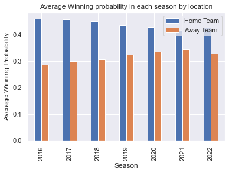

```python
serie_a_matches_played.groupby('season')[['prob1', 'prob2']].mean().plot(kind='bar')
plt.title("Average Winning probability in each season by location")
plt.xlabel('Season')
plt.ylabel('Average Winning Probability')
plt.legend(['Home Team', 'Away Team'])
plt.show()
```

The plot shows that the home team have an overall higher probability of winning compared to the away team.

To have a more thorough view, I will display the specific values of the winning probabilty using a line plot.

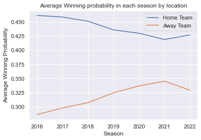

```python
home_team_prob = serie_a_matches_played.groupby('season')['prob1'].mean()
away_team_prob = serie_a_matches_played.groupby('season')['prob2'].mean()
fig, ax = plt.subplots()
ax.plot(home_team_prob.index, home_team_prob.values, label='Home Team')
ax.plot(away_team_prob.index, away_team_prob.values, label='Away Team')
ax.set_xlabel('Season')
ax.set_ylabel('Average Winning Probability')
plt.title("Average Winning probability in each season by location")

ax.legend()
plt.show()
```

From this plot, it is possible to see that the probability of winning of the away team has been very slowingly increasing, while the one from the home team is slightly decreasing.Nevertheless, the home team seems to have an advantage.

After seeing the average winning probability, I will now plot another importan feature to help us understand the performance of each team: the average of goal scored by the home team and the away team during each season. Thus, helping us to have an overall view of which team (home or away) scored more goals (on average).

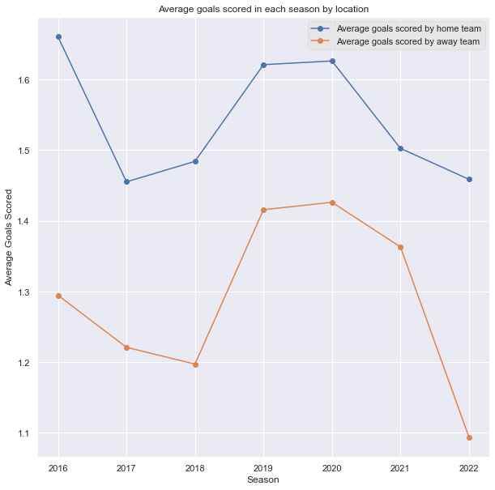

```python
seasons = serie_a_matches_played.season.unique()
fig = plt.figure(figsize=(10,10))
plt.title("Average goals scored in each season by location")
plt.xticks(range(len(seasons)), seasons)
plt.style.use('ggplot')
plt.xlabel("Season")
plt.ylabel("Average Goals Scored")
season = range(len(seasons))

plt.plot(season, serie_a_matches_played['home_team_goals'].groupby(serie_a_matches_played['season']).mean(),label= "Average goals scored by home team", marker = 'o')
plt.plot(season, serie_a_matches_played['away_team_goals'].groupby(
    serie_a_matches_played['season']).mean(), label="Average goals scored by away team", marker='o')

plt.legend()
```

From this plot, we can analyse that the teams playing in their own stadium scored more goals (on average) than the teams playing away. By scoring more goals than the opposition, the home teams had a better probability to win. Therefore, we can now visualize the trend of the average points gained by the home team against the ones of the away team.

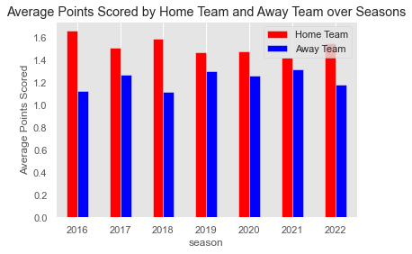

```python
serie_a_matches_played.groupby('season')['points_home', 'points_away'].mean(
).plot(kind='bar', color=["red", "blue"])
plt.title("Average Points Scored by Home Team and Away Team over Seasons")
plt.ylabel("Average Points Scored")
plt.grid(axis='y', linestyle='--')
plt.xticks(rotation=0)
plt.legend(["Home Team", "Away Team"])
plt.show()
```

This plot confirms that on average, the home teams gained more points than the away teams.

From these plots, we can deduce that throughout the last 6 years, the team that is playing in its home stadium may have an advantage over the visitor team.

## Training and evaluation using Logistic Regression and Support Vector Machines

The goal of this project is to to predict the winning team (home team or away team) based on features such as the probabilities of winning, tie or lose and the projected score of each team. I will use: Logistic Regression(LR) and Support Vector Machines(SVM) to train a model. Since this is a classification problem, the variable I want to predict(winning team) has three possible outcomes (without any specific order).

The possible outcomes are:

- 1 if the home team wins
- 2 if the away team wins
- 0 if there is a draw among the two teams

The choice of these numbers (1,2,0) it is very similar to the one used for the classic betting system in Italy (1,2,X).

All in all, this classification problem is multinomial, as there are more than 2 possible outcomes, therefore it is fundamental to adapt the way I will predict the values with Logistic Regression and Support Vector Machines.

For Logistic Regression I will use Multinomial Logistic Regression method to generalize the Logistic Regression to this multiclass problem.

In the case of SVM, it will also be adapted to a multinomial model by using a one vs rest. I choose "one vs rest" instead of "one vs one" because it is less costly in terms of computation.

Before starting using Logistic Regression and Support Vector Machines, I will need to insert the column "winning team" in the dataframe. To have a more accurate view, I will create two different dataframes, as I am interesting in the results when Napoli is playing as the home team or when is playing as the away team. Therefore, I will filter the dataframe of matches played by the team and the I will insert the "winning team" column.

```python
serie_a_matches_played_home_team = serie_a_matches_played[(
    serie_a_matches_played['home_team'] == 'Napoli')]
serie_a_matches_played_home_team.reset_index(drop=True, inplace=True)
serie_a_matches_played_home_team["winning team"] = np.where(
    serie_a_matches_played_home_team['points_home'] > serie_a_matches_played_home_team['points_away'], 1, np.where(serie_a_matches_played_home_team['points_home'] < serie_a_matches_played_home_team['points_away'], 2, 0))

serie_a_matches_played_away_team = serie_a_matches_played[(
    serie_a_matches_played['away_team'] == 'Napoli')]

serie_a_matches_played_away_team["winning team"] = np.where(
    serie_a_matches_played_away_team['points_home'] > serie_a_matches_played_away_team['points_away'], 1, np.where(serie_a_matches_played_away_team['points_home'] < serie_a_matches_played_away_team['points_away'], 2, 0))
```

### Logistic Regression

I will start by showing the prediction with Logistic Regression. I will filter the data by selecting only the columns of interest and split it into training and test set. Then I will make the predictions.

```python
X_lg_home = serie_a_matches_played_home_team[[
    'prob1', 'prob2', 'probtie', 'proj_score1', 'proj_score2']]
y_lg_home = serie_a_matches_played_home_team['winning team']

X_train_lg_home, X_test_lg_home, y_train_lg_home, y_test_lg_home = train_test_split(X_lg_home, y_lg_home, test_size=0.25, random_state=0)

model = LogisticRegression(multi_class='auto', random_state=0)
model.fit(X_train_lg_home, y_train_lg_home)

y_pred_home = model.predict(X_test_lg_home)
```

```python
X_lg_away = serie_a_matches_played_away_team[['prob1', 'prob2', 'probtie', 'proj_score1', 'proj_score2']]
y_lg_away = serie_a_matches_played_away_team['winning team']

X_train_lg_away, X_test_lg_away, y_train_lg_away, y_test_lg_away = train_test_split(X_lg_away, y_lg_away, test_size=0.25, random_state=0)

model_away = LogisticRegression(multi_class='auto', random_state=0)
model_away.fit(X_train_lg_away, y_train_lg_away)

y_pred_away = model_away.predict(X_test_lg_away)
```

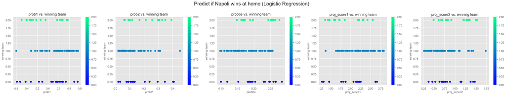

```python
feature_names_logistic_home = X_train_lg_home.columns

fig, axs = plt.subplots(1, len(feature_names_logistic_home), figsize=(35, 5))
plt.suptitle( "Predict if Napoli wins at home (Logistic Regression)", fontsize=20, y=1.05)

for i, feature_name in enumerate(feature_names_logistic_home):
    scatter = axs[i].scatter(X_train_lg_home[feature_name], y_train_lg_home,c=y_train_lg_home, s=50, cmap='winter')
    axs[i].set_xlabel(feature_name)
    axs[i].set_ylabel('winning team')
    cbar = plt.colorbar(scatter, ax=axs[i])
    axs[i].set_title(f"{feature_name} vs. winning team")
plt.show()
```

Let's plot the results obtained with the analysis of the away team.

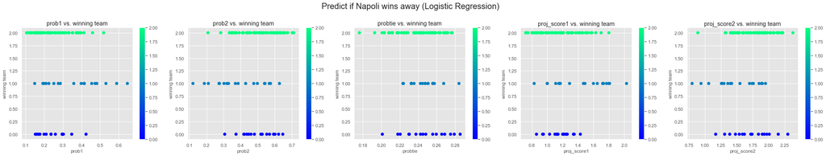

```python
feature_names_logistic_away = X_train_lg_away.columns

fig, axs = plt.subplots(1, len(feature_names_logistic_away), figsize=(35, 5))
plt.suptitle("Predict if Napoli wins away (Logistic Regression)",
             fontsize=20, y=1.05)

for i, feature_name in enumerate(feature_names_logistic_away):
    scatter = axs[i].scatter(X_train_lg_away[feature_name], y_train_lg_away, c=y_train_lg_away, s=50, cmap='winter')
    axs[i].set_xlabel(feature_name)
    axs[i].set_ylabel('winning team')
    cbar = plt.colorbar(scatter, ax=axs[i])
    axs[i].set_title(f"{feature_name} vs. winning team")

plt.show()
```

### Support Vector Machines (SVM)

Now let's analyse the performances using SVM. Also here, I will select only the columns of interest, split the dataframe into training and test set and predict the values.

```python
X_svm = serie_a_matches_played_home_team[['prob1', 'prob2', 'probtie', 'proj_score1', 'proj_score2']]
y_svm = serie_a_matches_played_home_team['winning team']

X_train, X_test, y_train, y_test = train_test_split(X_svm, y_svm, test_size=0.25, random_state=0)

model_svc = SVC(kernel ='rbf', C=1)
o_vs_r_home = OneVsRestClassifier(model_svc)


o_vs_r_home.fit(X_train, y_train)

y_pred = o_vs_r_home.predict(X_test)
```

Now, we try to see how the model perform with the away team.

```python
X_svm2 = serie_a_matches_played_away_team[['prob1', 'prob2', 'probtie', 'proj_score1', 'proj_score2']]
y_svm2 = serie_a_matches_played_away_team['winning team']

X_train2, X_test2, y_train2, y_test2 = train_test_split(
    X_svm2, y_svm2, test_size=0.25, random_state=0)

model_svc2 = SVC(kernel='rbf', C=1)
o_vs_r_away = OneVsRestClassifier(model_svc2)

o_vs_r_away.fit(X_train2, y_train2)

y_pred2 = o_vs_r_away.predict(X_test2)
```

After obtaining the accuracy score of SVM, we plot the data obtained. We start by displaying the results obtained of Napoli as the home team and then a plot of the results obtained of Napoli the visitor or away team.

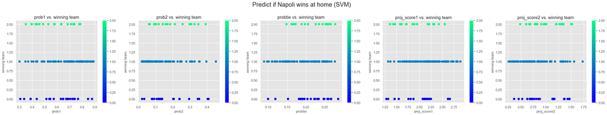

```python
feature_names_home = X_svm.columns

fig, axs = plt.subplots(1, len(feature_names_home), figsize=(35, 5))
plt.suptitle("Predict if Napoli wins at home (SVM)",
             fontsize=20, y=1.05)

for i, feature_name in enumerate(feature_names_home):
    scatter = axs[i].scatter(X_svm[feature_name], y_svm,  c=y_svm, s=50, cmap='winter')
    axs[i].set_xlabel(feature_name)
    axs[i].set_ylabel('winning team')
    cbar = plt.colorbar(scatter, ax=axs[i])
    axs[i].set_title(f"{feature_name} vs. winning team")

plt.show()
```

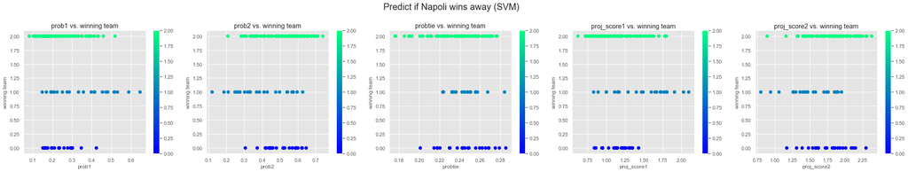

```python
feature_names_away = X_svm2.columns

fig, axs = plt.subplots(1, len(feature_names_away), figsize=(35, 5))
plt.suptitle("Predict if Napoli wins away (SVM)",
             fontsize=20, y=1.05)
for i, feature_name in enumerate(feature_names_away):
    scatter = axs[i].scatter(X_svm2[feature_name], y_svm2, c=y_svm2, s=50, cmap='winter')
    axs[i].set_xlabel(feature_name)
    axs[i].set_ylabel('winning team')
    cbar = plt.colorbar(scatter, ax=axs[i])
    axs[i].set_title(f"{feature_name} vs. winning team")

plt.show()
```

### Evaluation and compairison of the two models

To evaluate the performances of the SVM and LR models I will use three different metrics:

- F1_Score which shows us how much inaccuracy we should expect from the forecast on average
- Accuracy Score which evaluates the accuracy score for a set of predicted labels against the true labels
- Cross Validation (CV) which is a procedure used to estimate the skill of the model on new data

```python
f1_svm = f1_score(y_test, y_pred, average='weighted')
f1_lg = f1_score(y_test_lg_home, y_pred_home, average='weighted')
f1_svm_away = f1_score(y_test2, y_pred2, average='weighted')
f1_lg_away = f1_score(y_test_lg_away, y_pred_away, average='weighted')

print("SVM f1_score home{: .2f}".format(f1_svm))
print("SVM f1_score away{: .2f}".format(f1_svm_away))

print("LR f1_score home{: .2f}".format(f1_lg))
print("LR f1_score away{: .2f}".format(f1_lg_away))
```

```
SVM f1_score home 0.68
SVM f1_score away 0.51
LR f1_score home 0.62
LR f1_score away 0.62
```

Before analysing the f1_score of the two models, we also compute the accuracy_score that will give us a better view of the accuracy of the two models

```python
acc_svm = accuracy_score(y_test, y_pred)
acc_lg = accuracy_score(y_test_lg_home, y_pred_home)
acc_svm_away = accuracy_score(y_test2, y_pred2)
acc_lg_away = accuracy_score(y_test_lg_away, y_pred_away)

print("SVM accuracy score home{: .2f}".format(acc_svm))
print("SVM accuracy score away{: .2f}".format(acc_svm_away))

print("LR accuracy score home{: .2f}".format(acc_lg))
print("LR accuracy score away{: .2f}".format(acc_lg_away))
```

```
SVM accuracy score home 0.77
SVM accuracy score away 0.65
LR accuracy score home 0.65
LR accuracy score away 0.71
```

From these results we can see that:

- The LR is providing slightly better performances than SVM for predicting the away final result
- For the home final result SVM seems to be more accurate than LR

I will plot these results to have a better understanding:

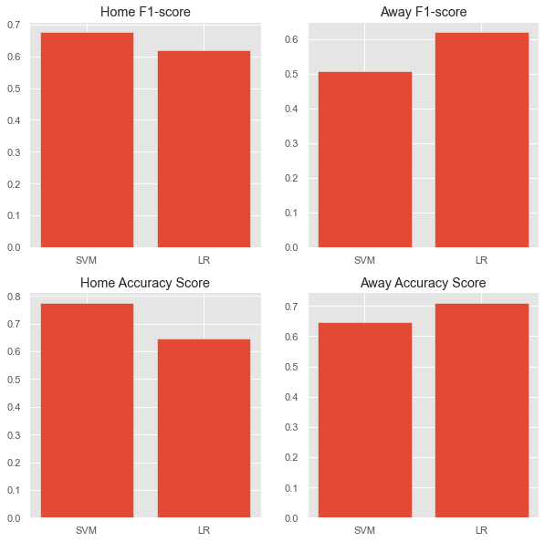

```python
fig, axs = plt.subplots(2, 2, figsize=(10, 10))

axs[0, 0].bar(['SVM', 'LR'], [f1_svm, f1_lg])
axs[0, 0].set_title('Home F1-score')
axs[0, 1].bar(['SVM', 'LR'], [f1_svm_away, f1_lg_away])
axs[0, 1].set_title('Away F1-score')

axs[1, 0].bar(['SVM', 'LR'], [acc_svm, acc_lg])
axs[1, 0].set_title('Home Accuracy Score')
axs[1, 1].bar(['SVM', 'LR'], [acc_svm_away, acc_lg_away])
axs[1, 1].set_title('Away Accuracy Score')

plt.show()
```

Now, I will use the process of cross-validation. It involves training a model on several subsets of data and then assessing its performance on the remaining data. The results are shown as mean accuracy plus or minus standard deviation.

```python
scores_svm = cross_val_score(model_svc, X_svm, y_svm, cv=5)
print("Cross-validation score SVM home: {:.2f} +/- {:.2f}".format(scores_svm.mean(), scores_svm.std()))

scores_svm = cross_val_score(model_svc2, X_svm2, y_svm2, cv=5)
print("Cross-validation score SVM away: {:.2f} +/- {:.2f}".format(scores_svm.mean(), scores_svm.std()))

scores_rf = cross_val_score(model, X_lg_home, y_lg_home, cv=5)
print("Cross-validation score Logistic Regression home: {:.2f} +/- {:.2f}".format(scores_rf.mean(), scores_rf.std()))

scores_rf = cross_val_score(model_away, X_lg_away, y_lg_away, cv=5)
print("Cross-validation score Logistic Regression away: {:.2f} +/- {:.2f}".format(scores_rf.mean(), scores_rf.std()))
```

```
Cross-validation score SVM home: 0.66 +/- 0.01
Cross-validation score SVM away: 0.66 +/- 0.04
Cross-validation score Logistic Regression home: 0.64 +/- 0.02
Cross-validation score Logistic Regression away: 0.68 +/- 0.05
```

From the Cross-validation we gained the following insights:

- The cross-validation scores' standard deviation is reasonably low, showing that the models' performance is consistent across various data subsets
- It seems that the LR is slightly better in predicting the away team compared to SVM, whereas the LR and SVM shows close scores for the home team

### Conclusions

In conclusion, it is important to point out that the performances of the model are affected also by the team that we are analysing and that there are too many variables that we cannot consider for having a generalized model for every team.

Nevertheless, according to the research results we can answer the research questions presented at the beginning:

1. Are we able to predict the future based on past events?  
   It is still very difficult to answer this question, however the obtained results are promising and there is room for improvements.
2. Will the obtained results be accurate?  
   The accuracy will depend on the team that we are analysing. In the case presented in this project, the SVM model has a higher F1-score for predicting whether a team is going to win/lose/draw while playing as the home team compared to LR model Whereas the LR has a higher F1-score for predicting whether a team is going to win/lose/draw while playing as the away team.
3. Which machine learning model is better for predicting the outcome of a match?  
   Since the results change according to the team of interest, it is still not clear which model among SVM or LR is the best. Nevertheless, the obtained results have shown that a solution could be to use SVM for predicting whether a team is going to win/lose/draw while playing as the home team and use LR for predicting whether a team is going to win/lose/draw while playing as the away team.

### Critical Assessment

Nevertheless, there is still room for improvement.

The performances are still somehow inconsistent. Overall, the values of the score may change according to the team we are analysing for the following reasons:

- Some teams have not played the same championship every year, thus because of the relegation process
- The team's performances have been affected by numerous situations that could have not been depicted in the dataframe (injuries, mental issues, underperformance, etc.)
- The team's performances are contradictory, therefore predicting goal scored or points gained leads to irregular results

One of the possible future work could be to find a dataframe containing the statistics about the players of the team and the other key events that are happening in a match such as injuries, red or yellow cards, etc. Thus, to find out the key players and how their performances influence the way the team performed in the match and possibly, how it can perform in the future.